# R4MS - Workshop 3

Author

Katie Dyck

Published

June 14, 2026

# 1 Introduction

For this workshop, I will be deconstructing a plot from the Coral Reef Fisheries module on the Reef Resilience Network website. The plot shows global trends in marine fish stock status from 1974 to 2009, with data points representing the percentage of fish stocks that are fully exploited, partially exploited, or underexploited. I will obtain raw data from this plot as accurately as possible, and then reconstruct the plot using R coding techniques taught in earlier workshops.

# 2 Housekeeping

Purge the global environment with the command `rm(list = ls())`.

# 3 Load packages

Package libraries needed for this module are `tidyverse` and `here`.

# 4 Exercise 1: Plot Deconstruction

## 4.1 Find the raw data

I chose to use the first graph from this webpage: https://reefresilience.org/coral-reef-fisheries-module/coral-reef-fisheries/overfishing/.

## 4.2 Wrangle the data

I want to first rename the columns so I know what variables I am working with.

```r
fish <- fish |>
    rename(date = "x", percent = "y")

fish
```

| date | percent |
| --- | --- |
| 1974-1-11 17:42:45 | 50.954381 |
| 1978-1-3 6:5:31 | 50.719566 |
| 1979-2-4 22:57:48 | 50.457448 |
| 1981-2-9 3:55:8 | 49.487524 |
| 1983-1-7 5:40:46 | 53.307570 |
| 1985-3-7 9:44:8 | 50.311266 |
| 1986-12-6 17:16:52 | 44.335462 |
| 1989-1-18 23:23:46 | 42.860623 |
| 1990-2-9 5:29:19 | 50.676300 |
| 1992-1-8 6:26:3 | 46.153071 |

[output cut: 41 more lines]

Next I will categorize each row of data into one of three categories: fully exploited, partially exploited, or underexploited. I will do this by creating a new column called `exploit_type` and using the `case_when()` function to assign the appropriate category based on the row number.

```r
fish <- fish |>
  mutate(
    exploit_type = case_when(
        row_number() %in% 1:17 ~ "fully_exp",
        row_number() %in% 18:34 ~ "partial_exp",
        row_number() %in% 35:51 ~ "under_exp",
        TRUE ~ NA_character_ # Assign NA to rows outside the specified ranges
    )
  )

fish
```

| date | percent | exploit_type |
| --- | --- | --- |
| 1974-1-11 17:42:45 | 50.954381 | fully_exp |
| 1978-1-3 6:5:31 | 50.719566 | fully_exp |
| 1979-2-4 22:57:48 | 50.457448 | fully_exp |
| 1981-2-9 3:55:8 | 49.487524 | fully_exp |
| 1983-1-7 5:40:46 | 53.307570 | fully_exp |
| 1985-3-7 9:44:8 | 50.311266 | fully_exp |
| 1986-12-6 17:16:52 | 44.335462 | fully_exp |
| 1989-1-18 23:23:46 | 42.860623 | fully_exp |
| 1990-2-9 5:29:19 | 50.676300 | fully_exp |
| 1992-1-8 6:26:3 | 46.153071 | fully_exp |

[output cut: 41 more lines]

In the `date` column I am only concerned about the year, so I will remove the month, day, and time information and create a new column called `year`. I will then remove the `date` column from the data frame.

```r
fish <- fish |>
  mutate(year = year(date), .after = date) |>
  select(-date)

fish
```

| year | percent | exploit_type |
| --- | --- | --- |
| 1974 | 50.954381 | fully_exp |
| 1978 | 50.719566 | fully_exp |
| 1979 | 50.457448 | fully_exp |
| 1981 | 49.487524 | fully_exp |
| 1983 | 53.307570 | fully_exp |
| 1985 | 50.311266 | fully_exp |
| 1986 | 44.335462 | fully_exp |
| 1989 | 42.860623 | fully_exp |
| 1990 | 50.676300 | fully_exp |
| 1992 | 46.153071 | fully_exp |

[output cut: 41 more lines]

## 4.3 Completed plot

Here is my final version of the plot, which is a recreation of the original plot from the Reef Resilience Network website. I used the `ggplot2` package to create the plot, and I added points for each data point, a linear regression line for each exploitation type, and customized the axes and labels.

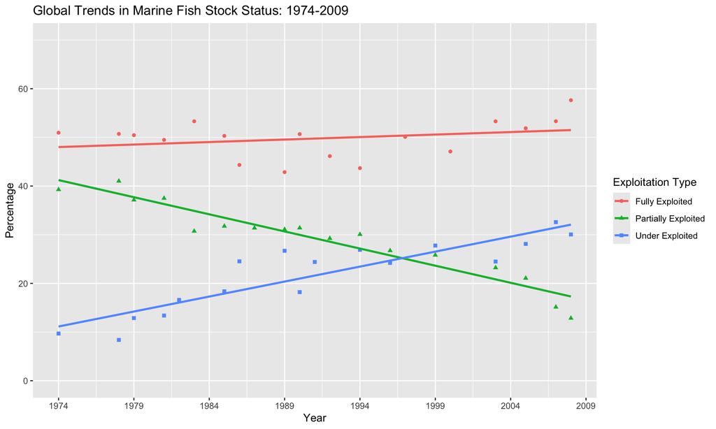

```r
ggplot(fish, aes(x = year, y = percent, colour = exploit_type, shape = exploit_type)) +
  geom_point() +
  geom_smooth(method = "lm", se = FALSE) +
  scale_y_continuous(limits = c(0,70)) +
  scale_x_continuous(breaks = seq(1974, 2009, by = 5)) +
  scale_color_discrete(labels = c("Fully Exploited", "Partially Exploited", "Under Exploited")) +
  scale_shape_discrete(labels = c("Fully Exploited", "Partially Exploited", "Under Exploited")) +
  labs(x = "Year", y = "Percentage",
       title = "Global Trends in Marine Fish Stock Status: 1974-2009",
       colour = "Exploitation Type", shape = "Exploitation Type")
```